# Байесовские модели временных рядов

Doynikov A.

March 29, 2021

Пусть $y_t,t=1,...,T$ временной ряд. Задавая вероятностную модель ряда, необходимо определить совместное распределение $p(y_{1:T})$. В общем случае это требует задания всех зависимостей, что невозможно, или делать предположения о вероятностной независимости. Для примера в случае двоичных данных $y_t \in [0,1]$, совместное распреднление максимально $2^T-1$ соотношений. Один из возможных вариантов преодоления этой проблемы - передположение назависимости распределения $a$ при условии $b$.
$$p(a|b)= \frac{p(a,b)}{p(b)}$$
Обозначив $y_{1:T}$ как $a$ и $y_{1:T-1}$ как $b$ мы получим, что
$$p(y_{1:T})=p(y_{1:T} | y_{1:T-1}) p(y_{1:T-1})$$

Заменив $T$ на $T-1$ и, повторяя до $t=1$, получим
$$p(y_{1:T}) =\prod_{t=1}^T p(y_{t} | y_{1:t-1})$$

## Оценка

Пусть $\theta$ - параметр модели. Задача оценивания параметра $\theta$ по наблюдением $y_{1:T}$ предполагает зависимость распределения $p(\theta|y_{1:T})$. Байесовское правило связи априорного распределения с апостериорным гласит
$$\underbrace{p(\theta|y_{1:T})}_{апостериорное}=\frac{\underbrace{p(y_{1:T}|\theta)}_{правдопобие--}\underbrace{p(\theta)}_{априорное}}{\underbrace{p(y_{1:T})}_{частное}}$$
Апостериорное распределение используется для получения точечной оценки $\theta^{MAP}$ максимума апостерирного распределения (MAP - maximum a posteriori) по параметру $\theta$
$$\theta^{MAP}=argmax_{\theta}[p(y_{1:T}\ |\theta)p(\theta)]$$
Вычислительно более удобно использовать логарифм апостериорного распределения
$$\theta^{MAP}=argmax_{\theta}[ln(p(y_{1:T} |\theta)p(\theta))]$$
Если предположить, что $p(\theta)= const$, то MAP оценка сводится к оценке максимального правдоподобия (ML)
$$\theta^{ML}=argmax_{\theta}[ln(p(y_{1:T} |\theta)]$$

## Сопряженные распределения

Важным понятием, значительно упрощающим вычисления, является понятие о сопряженных распределениях. Пусть $p(\theta)$ плотность априорного распределение параметра $\theta$. По теореме Байеса, апостериорное распределение вычисляется из априорного распределения с плотностью вероятности $p(\theta )$ и функции правдоподобия $p(x|\theta )$ по формуле:
$$p(\theta|x)=\frac{p(x|\theta)p(\theta)}{\int_{\theta}p(x|\theta)p(\theta)d\theta}$$
Если апостериорное распределение $p(\theta |x)$ принадлежит к тому же семейству вероятностных распределений, что и априорное распределение $p(\theta)$ (т.е. имеет тот же вид, но с другими параметрами), то это семейство распределений называется сопряжённым семейству функций правдоподобия $p(x|\theta)$. При этом распределение $p(\theta)$ называется сопряжённым априорным распределением к семейству функций правдоподобия $p(x|\theta)$.

Знание сопряжённых семейств распределений существенно упрощает вычисление апостериорных вероятностей в байесовской статистике, так как позволяет заменить вычисление громоздких интегралов в формуле Байеса простыми алгебраическими манипуляциями над параметрами распределений.

### Пример 1.

Для случайной величины, распределённой по закону Бернулли (бросание монетки) с неизвестным параметром $q\in [0,1]$ (вероятность успеха), в качестве сопряжённого априорного распределения обычно выступает бета-распределение с плотностью вероятности:
$$p(q=x)=\frac{x^{\alpha-1}(1-x)^{\beta-1}}{B(\alpha,\beta)}$$
где $B(\alpha,\beta)$- — бета-функция

### Пример 2.

Для случайной величины, распределенной нормально с известным математическим ожиданием $\mu$ и неизвестной дисперсией $\sigma^2$ в качестве сопряжённого априорного распределения обычно выступает обратное гамма распределение.

#### Гамма распределение

Про случайную величину $\xi$ говорят, что она имеет гамма распределение c параметрами $\alpha,\gamma$, если ее плотность вероятности
$$p(x)=\frac{x^{\alpha-1}}{\Gamma(\alpha)\gamma^{\alpha}}e^{-\frac{x}{\gamma}}$$

#### Обратное гамма распределение

Обратное гамма распределение получается из плотности гамма распределения заменой $y=|\sqrt{1/x}|$ или $y^2=\frac{1}{x}$ Таким образом случайная величина с плотностью вероятностей
$$p(y)=\frac{2}{\Gamma(\alpha)\gamma^{\alpha}y^{2\alpha+1}} e^{-\frac{1}{\gamma y^2}}$$
называется обратно гамма распределенной случайной величиной.

## Bayesian Structural Time Series Model (BSTS-Модель)

В последнее время интерес к Байесовским моделям временных рядов значительно возрос. Многие считают ,что эти модели эти модели значительно первосходят традиционные и некогда очень популярные ARIMA модели,особенно при прогнозировании. Характерным примером является появление работ подобно этой https://multithreaded.stitchfix.com/blog/2016/04/21/forget-arima/.

Bayesian structural time series (BSTS) модели специально разработаны для прогнозирования временных рядов.

Пусть $y_t$ обозначает наблюдение в момент времени $t$ во временном ряду с дейсвительными значениями . BSTS модель временного ряда описывается парой уравненеий относительно $y_t$ и вектора скрытых (латентных) переменных состояний $\alpha_t$.
$$y_t = Z^T_t\alpha_t+\epsilon_t,\mspace{25mu}\epsilon_t\sim \mathcal N(0,\sigma^2)$$
$$\alpha_{t+1} = T_t \alpha_t+ R_t\eta_t\mspace{25mu}\eta_t\sim \mathcal N(0,Q_t)$$
Первое уравнение назвается уравнением *наблюдений* потому, что оно связывает наблюдаемемые величины $y_t$ с ненаблюдаемыми (латентными) состояниями $\alpha_t$. Второе уравнение называется уравнением *перехода* потому, что оно определяет динамику изменения латентных переменных во времени. Матрицы $Z_t$, $T_t$, and $R_t$ обычно состоят из наборов известных величин (часто 0 или 1) и неизвестных параметров. Матрица перехода $T_t$ - квадратная , но $R_t$ может быть прямоугольной, когда часть состояний не является случайной.

Множество моделей временных рядов ,включая ARIMA, может быть представлена в такой форме, что позднее и продемонстрируем.

## Пример 1. Модель локального уровня (Local level model).

Простейшей моделью временного ряда является модель локального уровня, в которой вектор $\alpha_t$ есть просто скалярная величина, задающая уровень $\mu_t$ . Модель локального уровня это случайное блуждание.
$$y_t=\mu_t+\epsilon_t, \mspace{25mu}\epsilon_t\sim \mathcal N (0, \sigma^2_{\epsilon})$$

$$\mu_{t+1}=\mu_t+\eta_t, \mspace{25mu}\eta_t\sim \mathcal N (0, \sigma^2_{\eta}).$$

Здесь $\alpha_t=\mu_t$ , и матрицы $Z_t , T_t$ , и $R_t$ сводятся к скаляру равному 1. Параметрами модели являются дисперсии $\epsilon_t \sim\mathcal N(0,\sigma^2)$ и $\eta_t\sim \mathcal N(0,\tau^2)$ .

Рассмотрим работу с этой моделью на примере ряда количества осадков в Лос-Анжелесе из пакета TSA.

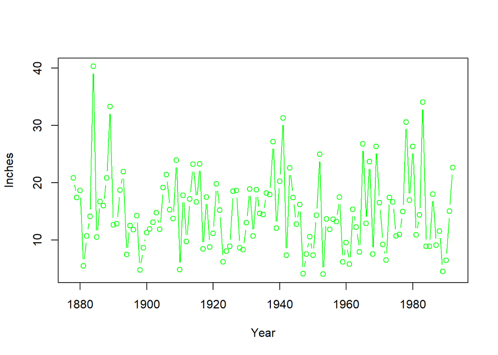

```r
data(larain)
plot(larain,ylab='Inches',type = 'b',xlab='Year',pch = 21,col = 'green')
```

Сначала лист спецификаций,задающий модель, является пустым. Добавим к нему модель локального уровня для ряда наблюдений $y_t$- `larain`. Зададим априорное распределение `SdPrior()` для стандартного отклонения $\sigma_{\eta}$ в момент первый момент времени. Напомним, что для случайной величины, распределенной нормально с известным математическим ожиданием $\mu=0$ и неизвестной дисперсией $\sigma^2$ в качестве сопряжённого априорного распределения обычно выступает обратное гамма распределение. Далее начнем оценку BSTS модели моделированием. Всего проведем `niter = 500` итераций моделирования.

```r
ss <- list()
sd.prior <- SdPrior(sigma.guess = 0.3,sample.size = .01)
ss = AddLocalLevel(ss,larain,sigma.prior =sd.prior)
niter = 500
model.simple <- bsts(larain, state.specification = ss,sigma.prior = sd.prior, niter = niter)
```

```
## =-=-=-=-= Iteration 0 Mon Mar 29 23:56:24 2021
##  =-=-=-=-=
## =-=-=-=-= Iteration 50 Mon Mar 29 23:56:24 2021
##  =-=-=-=-=
## =-=-=-=-= Iteration 100 Mon Mar 29 23:56:24 2021
##  =-=-=-=-=
## =-=-=-=-= Iteration 150 Mon Mar 29 23:56:24 2021
##  =-=-=-=-=
## =-=-=-=-= Iteration 200 Mon Mar 29 23:56:24 2021
##  =-=-=-=-=
## =-=-=-=-= Iteration 250 Mon Mar 29 23:56:24 2021
##  =-=-=-=-=
## =-=-=-=-= Iteration 300 Mon Mar 29 23:56:24 2021
##  =-=-=-=-=
## =-=-=-=-= Iteration 350 Mon Mar 29 23:56:24 2021
##  =-=-=-=-=
## =-=-=-=-= Iteration 400 Mon Mar 29 23:56:24 2021
##  =-=-=-=-=
## =-=-=-=-= Iteration 450 Mon Mar 29 23:56:24 2021
##  =-=-=-=-=
```

Вычислим прогнозы на 12 единиц времени вперед ‘horizon = 12’ и нарисуем последние 20 `(plot.original = 20)`наблюдений ряда, прогноз среднего уровня и 95% доверительный интервал, построенный (по умолчанию) по `burn = SuggestBurn(0.5,model.simple)` выбранных итераций из общего числа итераций в `niter = 500` .

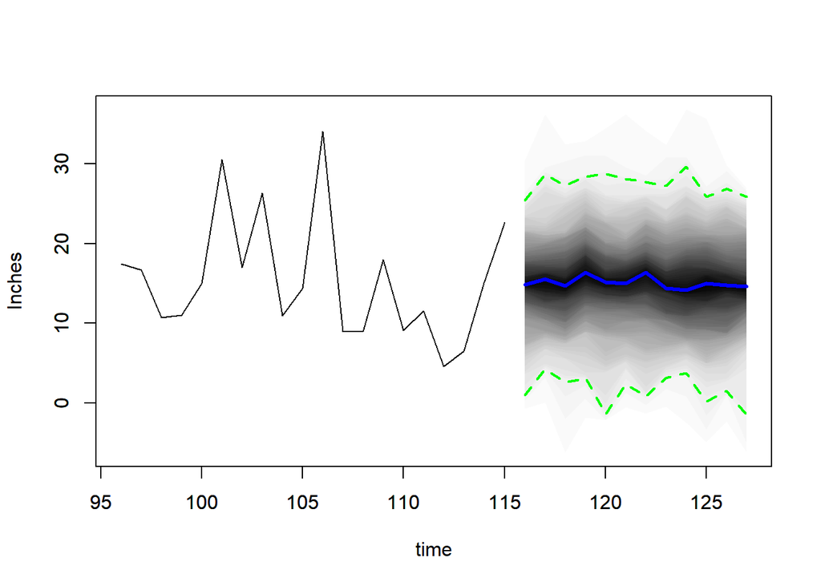

```r
pred.simple <- predict(model.simple, horizon = 12,burn = SuggestBurn(0.5,model.simple))
plot(pred.simple, plot.original = 20,ylab='Inches')
```

На рисунке виден средний значение прогноза и 95% доверительный интервал прогноза, построенный по распределению прогноза.

Величины средних значений, а таже медианы можно получить следующим образом

```r
pred.simple$mean
```

```
##  [1] 14.80616 15.16313 14.80148 16.19489 14.95113 15.11705 15.46306 14.71167
##  [9] 14.96888 14.46426 14.62168 14.61327
```

```r
pred.simple$median
```

```
##  [1] 14.80828 15.52625 14.69396 16.37178 15.14631 15.02011 16.35810 14.36963
##  [9] 14.14177 15.02238 14.72188 14.61143
```

Распределение прогноза находится в переменной `pred.simple$distribution` размера

```r
dim(pred.simple$distribution)
```

```
## [1] 123  12
```

```r
head(pred.simple$distribution)
```

```
##           [,1]      [,2]     [,3]     [,4]       [,5]     [,6]     [,7]
## [1,] 17.402667 16.227014 15.63759 11.59422  6.2019524 19.22520 12.41696
## [2,] 14.808280 23.109398 24.95424 20.04819 12.3080716 17.77969 16.35810
## [3,] 14.562383  8.334414 10.07007 16.47110 14.9548316 20.16703 13.52718
## [4,] 21.421616 21.537222 28.51185 22.09550 15.6744055 12.36089 16.75176
## [5,]  7.236125  7.290018 20.89072 15.56212  4.6234189 17.28844 12.36478
## [6,] 11.973233  8.444378 14.69396 16.94376  0.6878844 12.02391 13.58081
##           [,8]     [,9]     [,10]     [,11]     [,12]
## [1,] 10.281821 21.96827 14.510191 25.191198 26.867822
## [2,] 13.918538 16.93232 11.792072 19.601827 17.940379
## [3,]  4.066132 11.46924 22.789642 16.515649 -6.245713
## [4,] 14.156889 29.71847  7.395932 14.549280 21.783572
## [5,] 11.097749 20.72630 15.800717 14.866602 15.219751
## [6,]  4.690242 13.34844 13.004811  4.973097 20.659770
```

Обратите внимание ,что размер первого параметра в размерности `pred.simple$distribution` равен `niter-SuggestBurn(0.5,model.simple)`.

```r
niter - SuggestBurn(0.5,model.simple)
```

```
## [1] 123
```

## Пример 2.Локальный линейный тренд(Local linear trend ).

Чуть более сложной является модель с локальным линейным трендом. В этой модели оба параметра средний уровень $\mu_t$ и наклон $\nu_t$ ведут себя как случайное блуждание. Уравнения состояний и перехода для этой модели будут такие:

$$y_{t}= \mu_t+ \epsilon_t, \mspace{25mu}\epsilon_t\sim \mathcal N (0, \sigma^2_{\epsilon}).$$
$$\mu_{t+1}= \mu_t+ \nu_t+\xi_t, \mspace{25mu}\xi_t\sim \mathcal N (0, \sigma^2_{\xi}).$$
$$\nu_{t+1}=\nu_t+\zeta_t , \mspace{25mu}\zeta_t\sim \mathcal N (0, \sigma^2_{\zeta})$$

В локально линейной модели тренд получается добавлением компоненты наклон $\nu_t$ в модель лоепльного уровня. Уравнение состояний в модели локального линейного тренда состоит из двух уравнений: первое для моделирования уровня $\mu_t$ и второе для моделтрования наклона. Наклон $\nu_t$ эквивалентен параметру $b$ в классической регрессионной модели
$$y_t=a+bx_t+\epsilon_t$$

Величина b задает угол наклона линии регрессии с осью x. К параметрам предыдущий модели добавляется парапметр стандартного отклонения $\sigma_{\zeta}$ компоненты наклона $\nu_t$. Начальное значение которого в первый момент времени $t=1$ часто берут из оценки классической регрессионной модели. Посмотрим как это работает на примере ряды логарифмов числа пассажиров из пакета TSA.

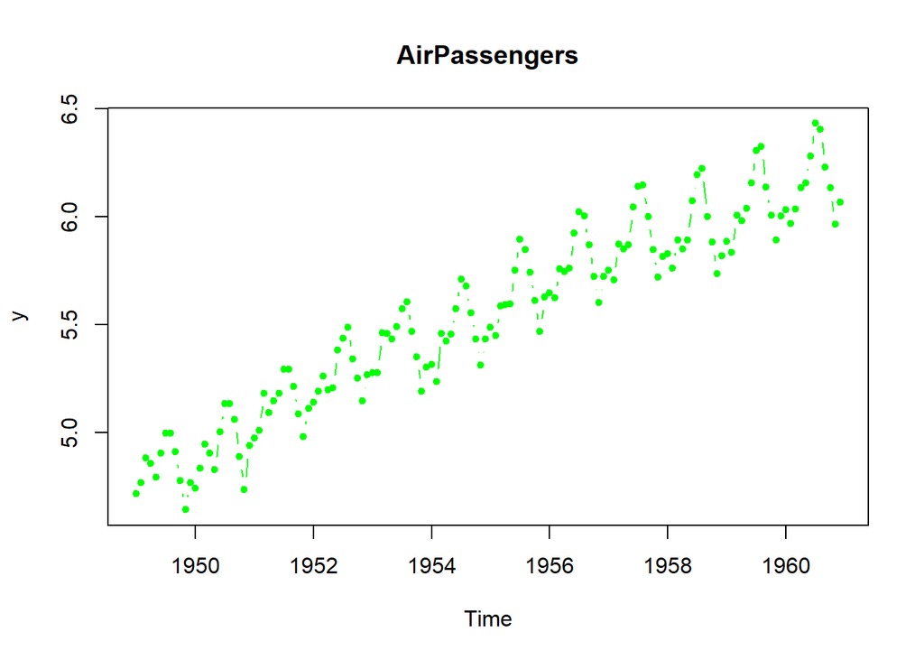

```r
data(AirPassengers)
y <- log(AirPassengers)
plot(y,type = 'b',pch = 20,col= 'green',main = 'AirPassengers')
```

```r
regr <- lm(y~time(y))
(sm <-summary(regr))
```

```
##
## Call:
## lm(formula = y ~ time(y))
##
## Residuals:
##      Min       1Q   Median       3Q      Max
## -0.30858 -0.10388 -0.01796  0.09738  0.29538
##
## Coefficients:
##               Estimate Std. Error t value Pr(>|t|)
## (Intercept) -2.302e+02  6.539e+00  -35.20   <2e-16 ***
## time(y)      1.206e-01  3.345e-03   36.05   <2e-16 ***
## ---
## Signif. codes:  0 '***' 0.001 '**' 0.01 '*' 0.05 '.' 0.1 ' ' 1
##
## Residual standard error: 0.139 on 142 degrees of freedom
## Multiple R-squared:  0.9015, Adjusted R-squared:  0.9008
## F-statistic:  1300 on 1 and 142 DF,  p-value: < 2.2e-16
```

```r
(sd.slope <- sm$coefficients[2,2])
```

```
## [1] 0.003344783
```

```r
(sd.level <- sm$coefficients[1,2])
```

```
## [1] 6.538923
```

Добавляем локальный линейный тренд в спецификации состояний и задаем для первого момента времени априорное распределение `SdPrior()` для стандартного отклонения наклона $\sigma_{\nu}$ и уровня $\mu_t$ из оценок линейной регрессионной модели Проведем моделирование BSTS модели `niter = 500` и как в предыдущей модели построим прогнозы с доверительными интервалами.

```r
slope.sigma.prior = SdPrior(sd.slope)
level.sigma.prior = SdPrior(sd.level)
ss <- AddLocalLinearTrend(ss, y,
              level.sigma.prior = level.sigma.prior,
              slope.sigma.prior = slope.sigma.prior)
model.local.linear <- bsts(y, state.specification = ss, niter = 500)
```

```
## =-=-=-=-= Iteration 0 Mon Mar 29 23:56:25 2021
##  =-=-=-=-=
## =-=-=-=-= Iteration 50 Mon Mar 29 23:56:25 2021
##  =-=-=-=-=
## =-=-=-=-= Iteration 100 Mon Mar 29 23:56:25 2021
##  =-=-=-=-=
## =-=-=-=-= Iteration 150 Mon Mar 29 23:56:26 2021
##  =-=-=-=-=
## =-=-=-=-= Iteration 200 Mon Mar 29 23:56:26 2021
##  =-=-=-=-=
## =-=-=-=-= Iteration 250 Mon Mar 29 23:56:26 2021
##  =-=-=-=-=
## =-=-=-=-= Iteration 300 Mon Mar 29 23:56:26 2021
##  =-=-=-=-=
## =-=-=-=-= Iteration 350 Mon Mar 29 23:56:26 2021
##  =-=-=-=-=
## =-=-=-=-= Iteration 400 Mon Mar 29 23:56:26 2021
##  =-=-=-=-=
## =-=-=-=-= Iteration 450 Mon Mar 29 23:56:26 2021
##  =-=-=-=-=
```

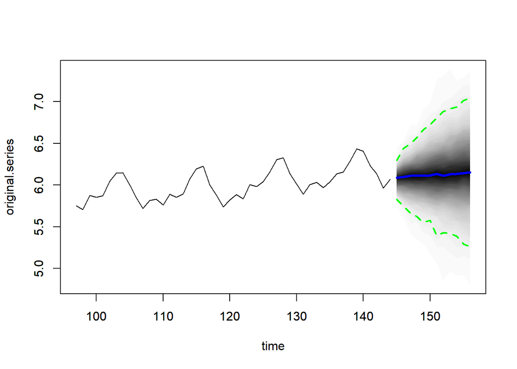

```r
pred.local.linear <- predict(model.local.linear, horizon = 12, burn = 100)
plot(pred.local.linear,plot.original = 48)
```

## Пример 2. Продолжение. Добавляем сезонную компоненту.

Теперь к предыдущему примеру добавим сезонную компоненту.

Если $S$ период сезонности, тогда вектор $\tau$ - вектор сезонной компоненты. По определению аддитивной сезонной компоненты, сумма вклада сезооности за весь период полагается рраной нулю, поэтому первая компонента вектора $\tau_t$ полагается равной минус сумме остальных
$$\tau_t =-\sum_{s=1}^{S-1}\tau_{t-s} +w_t,\mspace{25mu}w_t \sim \mathcal N (0, \sigma^2_{w}).$$

Итак, теперь наша в нашу BSTS модель из прошлого примера добавим эффект сезонности
$$y_{t+1}= y_t+ \nu_t + \tau_t+\epsilon_t, \mspace{25mu}\epsilon_t\sim \mathcal(N (0, \sigma^2_{\epsilon}).$$
$$\nu_{t+1} = \nu_t + \eta_t,\mspace{25mu} \eta_t \sim \mathcal N (0, \sigma^2_{\eta}).$$

$$\tau_t =-\sum_{s=1}^{S-1}\tau_{t-s}+ w_t,\mspace{25mu}w_t \sim \mathcal N (0, \sigma^2_{w}).$$
В качестве априорного распределения значений вектора сезонности в начальный момент времени положим нормальное распределение.

К переменной спецификаций `ss` из прошлого примера добавим сезонный эффект

```r
init.season.prior = NormalPrior(0, sigma = 10)
ss <- AddSeasonal(ss, y, nseasons = 12,initial.state.prior = init.season.prior)
```

Произведем оценку bsts модели согласно новым спецификациям и посмотрим на прогнозы с 95% доверительными интервалами.

```r
model.seasonal <- bsts(y, state.specification = ss, niter = 500)
```

```
## =-=-=-=-= Iteration 0 Mon Mar 29 23:56:27 2021
##  =-=-=-=-=
## =-=-=-=-= Iteration 50 Mon Mar 29 23:56:27 2021
##  =-=-=-=-=
## =-=-=-=-= Iteration 100 Mon Mar 29 23:56:27 2021
##  =-=-=-=-=
## =-=-=-=-= Iteration 150 Mon Mar 29 23:56:28 2021
##  =-=-=-=-=
## =-=-=-=-= Iteration 200 Mon Mar 29 23:56:28 2021
##  =-=-=-=-=
## =-=-=-=-= Iteration 250 Mon Mar 29 23:56:28 2021
##  =-=-=-=-=
## =-=-=-=-= Iteration 300 Mon Mar 29 23:56:28 2021
##  =-=-=-=-=
## =-=-=-=-= Iteration 350 Mon Mar 29 23:56:29 2021
##  =-=-=-=-=
## =-=-=-=-= Iteration 400 Mon Mar 29 23:56:29 2021
##  =-=-=-=-=
## =-=-=-=-= Iteration 450 Mon Mar 29 23:56:29 2021
##  =-=-=-=-=
```

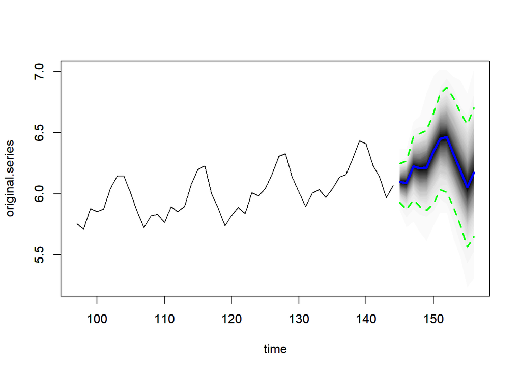

```r
pred.seasonal <- predict(model.seasonal, horizon = 12, burn = 100)
plot(pred.seasonal,plot.original = 48)
```

## Пример 3. AR(p) процесс как BSTS модель.

Рассмотрим реализацию BSTS модели на примере процесса авторегрессии AR(2). Сначала смоделируем процесс AR(2).

```r
n <- 100
residual.sd <- .001
# Actual values of the AR coefficients
phi <- c(-.4, .5)
ar <- arima.sim(model = list(ar = phi),
                n = n,
                sd = 3)
```

Компонента состояний в данном случае будет
$$\alpha_t = \phi_1\alpha_{t−1} + · · · + \phi_p\alpha_{t−p} + \epsilon_{t-1} \mspace{25mu}\epsilon_t \sim \mathcal N (0, \sigma^2)$$
Матрица перехода $T_t$ имеет первую строку как $\phi_i,i = 1,...2$ - параметры модели AR(2), единицы на главной диагонале в последующих строках и нули в остальных случаях. Ковариационная матрица $R$ в уравнении состояний имеет $\sigma^2$ в левом вершнем угле и ноль иначе. Матрица наблюдений $Z^T_t$ имеет 1 как первый элемент и ноль иначе.

Добавим некоторый шум к AR процессу.

```r
y <- ar + rnorm(n, 0, residual.sd)
```

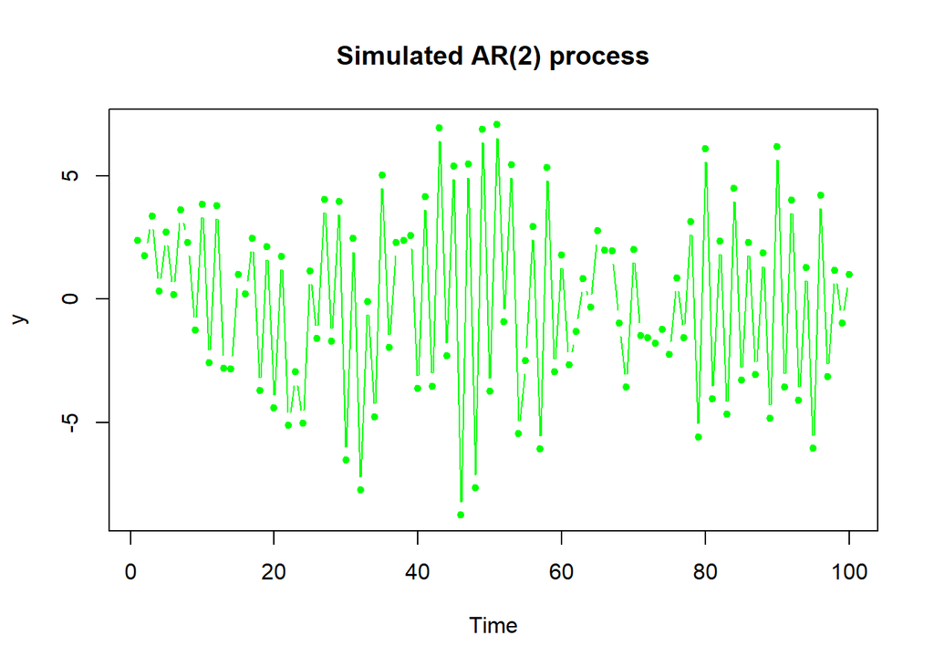

```r
plot(y,type = 'b',pch = 20,main = 'Simulated AR(2) process',ylab = 'y',col = 'green',xlab = 'Time')
```

Априорное распределение для стандартного отклонения процесса приращений традиционно является обратное гамма(see `SdPrior()` ).

Произведем оценку BSTS модели.

```r
ss <- AddAr(list(), lags = 2, sigma.prior = SdPrior(3.0, 1.0))
model <- bsts(y, state.specification=ss, niter = 500, prior = SdPrior(residual.sd, 100000))
```

```
## =-=-=-=-= Iteration 0 Mon Mar 29 23:56:30 2021
##  =-=-=-=-=
## =-=-=-=-= Iteration 50 Mon Mar 29 23:56:30 2021
##  =-=-=-=-=
## =-=-=-=-= Iteration 100 Mon Mar 29 23:56:30 2021
##  =-=-=-=-=
## =-=-=-=-= Iteration 150 Mon Mar 29 23:56:30 2021
##  =-=-=-=-=
## =-=-=-=-= Iteration 200 Mon Mar 29 23:56:30 2021
##  =-=-=-=-=
## =-=-=-=-= Iteration 250 Mon Mar 29 23:56:30 2021
##  =-=-=-=-=
## =-=-=-=-= Iteration 300 Mon Mar 29 23:56:30 2021
##  =-=-=-=-=
## =-=-=-=-= Iteration 350 Mon Mar 29 23:56:30 2021
##  =-=-=-=-=
## =-=-=-=-= Iteration 400 Mon Mar 29 23:56:30 2021
##  =-=-=-=-=
## =-=-=-=-= Iteration 450 Mon Mar 29 23:56:30 2021
##  =-=-=-=-=
```

```r
summary(model)
```

```
## $residual.sd
## [1] 0.0009999823
##
## $prediction.sd
## [1] 3.742605
##
## $rsquare
## [1] 0.9999999
##
## $relative.gof
## [1] 0.6937734
```

Сравним теоретическую АКФ с теоретической построенной по оценкам параметров модели

```r
 phi
```

```
## [1] -0.4  0.5
```

```r
 head(model$AR2.coefficients)
```

```
##      [,1] [,2]
## [1,]    0    0
## [2,]    0    0
## [3,]    0    0
## [4,]    0    0
## [5,]    0    0
## [6,]    0    0
```

```r
 tail(model$AR2.coefficients)
```

```
##        [,1] [,2]
## [495,]    0    0
## [496,]    0    0
## [497,]    0    0
## [498,]    0    0
## [499,]    0    0
## [500,]    0    0
```

```r
 colMeans(model$AR2.coefficients)
```

```
## [1] 0 0
```

Для сравнения добавим график эмпирической АКФ.

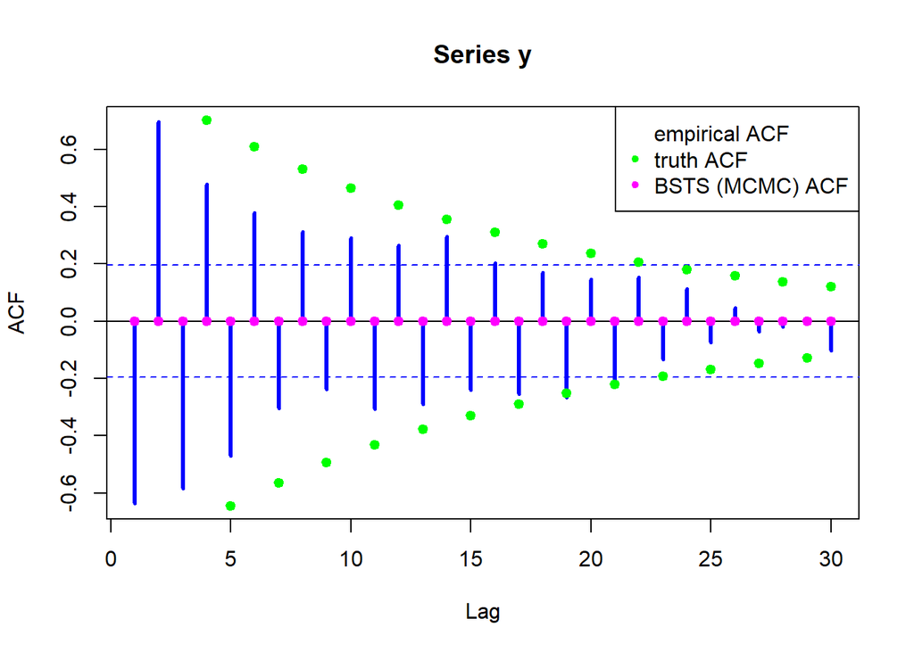

```r
acf(y, lag.max = 30,col = "blue",lwd = 3)
points(0:30, ARMAacf(ar = phi, lag.max = 30), pch = 20,col='green',lwd =3 )
points(0:30, ARMAacf(ar = colMeans(model$AR2.coefficients), lag.max = 30),pch =20,col = 'magenta',lwd =3)
legend("topright", leg = c("empirical ACF", "truth ACF", "BSTS (MCMC) ACF"), pch = c(NA, 20, 20),col = c('blue','green','magenta'))
```

Построим прогнозы на 12 отрезков времени вперед.

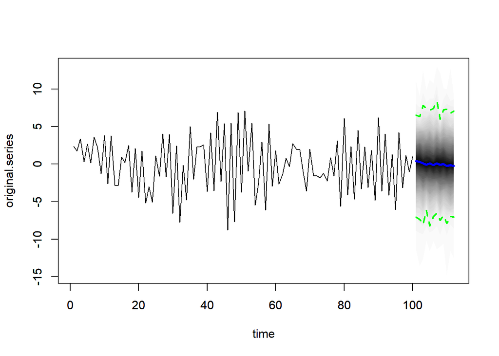

```r
pred.AR <- predict(model, horizon = 12, burn = 100)
plot(pred.AR)
```

## Пример 3. Недельный ряд цен на бензин (доллар за галлон)

Будем анализировать временной ряд цен на бензин. Недельные данные получены с сайта https://www.eia.gov/petroleum/gasdiesel/. Здесь BSTS модель будет иметь компоненты: тренд,сезонность и дополнительные регрессоры.

```r
historicData <- read.csv('./HistoricData.csv',header = TRUE)
historicData <- as.data.frame(historicData)
head(historicData)
```

```
##   ï..Date EMM_EPMRU     Date WGTSTUS1 WTTSTUS1  RWTC RBRTE
## 1 1/10/00     1.252 01/07/00   194173  1488583 24.95 23.64
## 2 1/17/00     1.268 01/14/00   198240  1486494 26.27 24.34
## 3 1/24/00     1.307 01/21/00   200815  1478838 29.37 26.38
## 4 1/31/00     1.307 01/28/00   201447  1465376 28.34 26.99
## 5  2/7/00     1.319 02/04/00   200937  1460659 28.08 27.33
## 6 2/14/00     1.350 02/11/00   199593  1453846 28.83 27.63
```

```r
ncol <- dim(historicData)[2]
nrow  <- dim(historicData)[1]
```

В дополнении к ценас на бензин файл содержит также следующие временные ряды:

- Weekly U.S. Ending Stocks of Total Gasoline (Thousand Barrels);
- Weekly U.S. Ending Stocks of Crude Oil and Petroleum Products (Thousand Barrels);
- Weekly Cushing, OK WTI Spot Price FOB (Dollars per Barrel);
- Weekly Europe Brent Spot Price FOB (Dollars per Barrel).

Все временные ряды синхронизированы по времени, причем цены на бензин даны через 3 календарных дня от всех предполагаемых регрессоров.

```r
gasolineDates <- as.Date(historicData[,1], "%m/%d/%y")
allDates <- as.Date(historicData[,3], "%m/%d/%y")
head(gasolineDates-allDates)
```

```
## Time differences in days
## [1] 3 3 3 3 3 3
```

```r
tail(gasolineDates-allDates)
```

```
## Time differences in days
## [1] 3 3 3 3 3 3
```

Для того чтобы исключить влияние разница в абсолютных значениях, данные по запасам нефти и бензина пронормированы в интервал от 0 до 1.

```r
historicData$WGTSTUS1<- historicData$WGTSTUS1/max(historicData$WGTSTUS1)
historicData$WTTSTUS1 <-historicData$WTTSTUS1/max(historicData$WTTSTUS1)
head(historicData)
```

```
##   ï..Date EMM_EPMRU     Date  WGTSTUS1  WTTSTUS1  RWTC RBRTE
## 1 1/10/00     1.252 01/07/00 0.7495204 0.7194208 24.95 23.64
## 2 1/17/00     1.268 01/14/00 0.7652193 0.7184112 26.27 24.34
## 3 1/24/00     1.307 01/21/00 0.7751589 0.7147111 29.37 26.38
## 4 1/31/00     1.307 01/28/00 0.7775985 0.7082050 28.34 26.99
## 5  2/7/00     1.319 02/04/00 0.7756299 0.7059253 28.08 27.33
## 6 2/14/00     1.350 02/11/00 0.7704419 0.7026326 28.83 27.63
```

Готовим данные для bsts модели.

```r
library(xts)
histData <- cbind(historicData[,2],historicData[,4:ncol])
```

Добавим к регрессорам заведомо не значащую переменную, просто последовательность ннезависимых нормально распределенных величин `rnorm(nrow)`, котороую назовем `dummy`.

```r
histData <- cbind(histData,rnorm(nrow))
```

Все ряды собираем в одну матрицу, делаем их типа `xts` - временной ряд, и затем весь набор объявляем типа `data.frame`.

```r
data.xts <- as.xts(histData, order.by = gasolineDates)
data.xts <- as.data.frame(data.xts)
col.names <- colnames(data.xts)
col.names[1]<- "y"
col.names[6]<-"dummy"
colnames(data.xts) <-col.names
head(data.xts)
```

```
##                y  WGTSTUS1  WTTSTUS1  RWTC RBRTE      dummy
## 2000-01-10 1.252 0.7495204 0.7194208 24.95 23.64  0.0774393
## 2000-01-17 1.268 0.7652193 0.7184112 26.27 24.34 -0.2558139
## 2000-01-24 1.307 0.7751589 0.7147111 29.37 26.38 -0.4108846
## 2000-01-31 1.307 0.7775985 0.7082050 28.34 26.99 -0.5535609
## 2000-02-07 1.319 0.7756299 0.7059253 28.08 27.33 -0.1602812
## 2000-02-14 1.350 0.7704419 0.7026326 28.83 27.63 -0.6105956
```

```r
data.xts <- as.xts(data.xts, order.by = gasolineDates)
```

Вначале давайте проигнормруем все регрессионные компоненты и оставим только локальный линейный тренд и сезонную компоненту.

```r
ss <- AddLocalLinearTrend(list(), data.xts$y)
ss <- AddSeasonal(ss, data.xts$y, nseasons = 52)
model.no.regressors <- bsts(data.xts$y,
               state.specification = ss,
               niter = 1000)
```

```
## =-=-=-=-= Iteration 0 Mon Mar 29 23:56:32 2021
##  =-=-=-=-=
## =-=-=-=-= Iteration 100 Mon Mar 29 23:56:43 2021
##  =-=-=-=-=
## =-=-=-=-= Iteration 200 Mon Mar 29 23:56:55 2021
##  =-=-=-=-=
## =-=-=-=-= Iteration 300 Mon Mar 29 23:57:07 2021
##  =-=-=-=-=
## =-=-=-=-= Iteration 400 Mon Mar 29 23:57:19 2021
##  =-=-=-=-=
## =-=-=-=-= Iteration 500 Mon Mar 29 23:57:31 2021
##  =-=-=-=-=
## =-=-=-=-= Iteration 600 Mon Mar 29 23:57:43 2021
##  =-=-=-=-=
## =-=-=-=-= Iteration 700 Mon Mar 29 23:57:54 2021
##  =-=-=-=-=
## =-=-=-=-= Iteration 800 Mon Mar 29 23:58:06 2021
##  =-=-=-=-=
## =-=-=-=-= Iteration 900 Mon Mar 29 23:58:18 2021
##  =-=-=-=-=
```

Пакет *bsts* содержит несколько удобных plot методов.

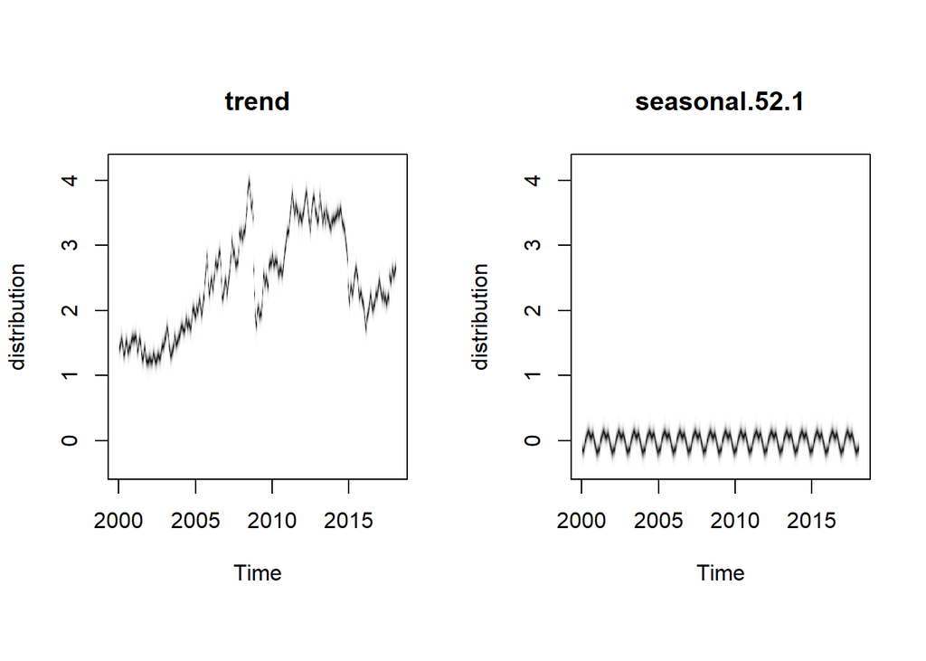

```r
#plot(model.no.regressors, "help")
plot(model.no.regressors, "components")
```

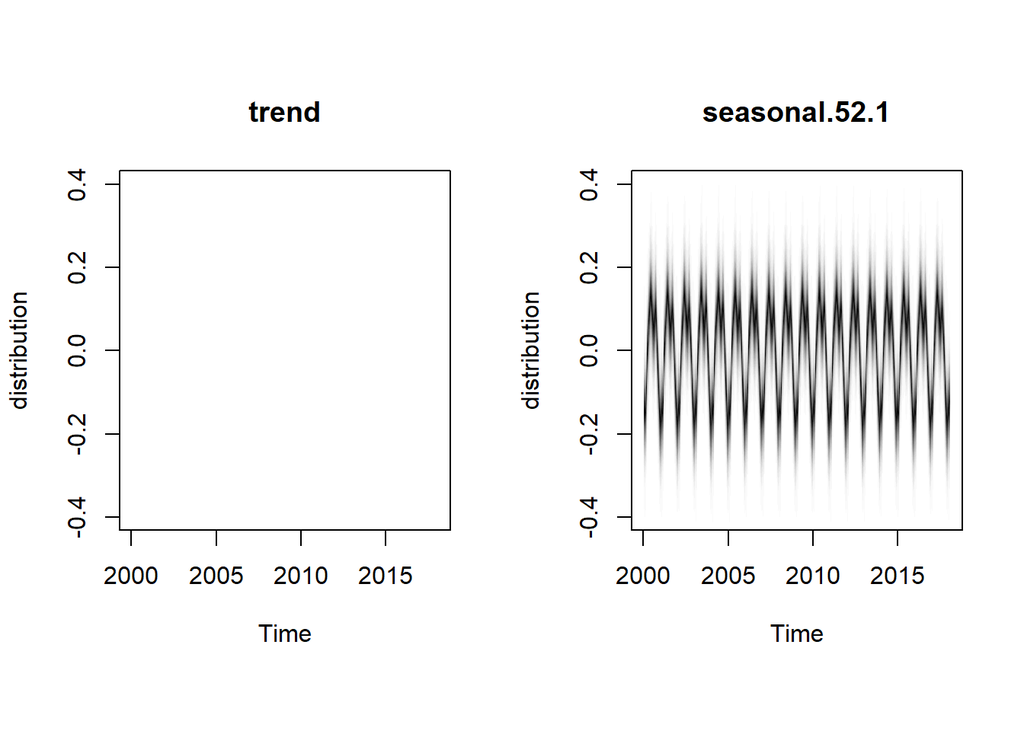

```r
plot(model.no.regressors, "components",ylim = c(-0.4,0.4))
```

Вывод апостериорного распределения вероятностей остатков.

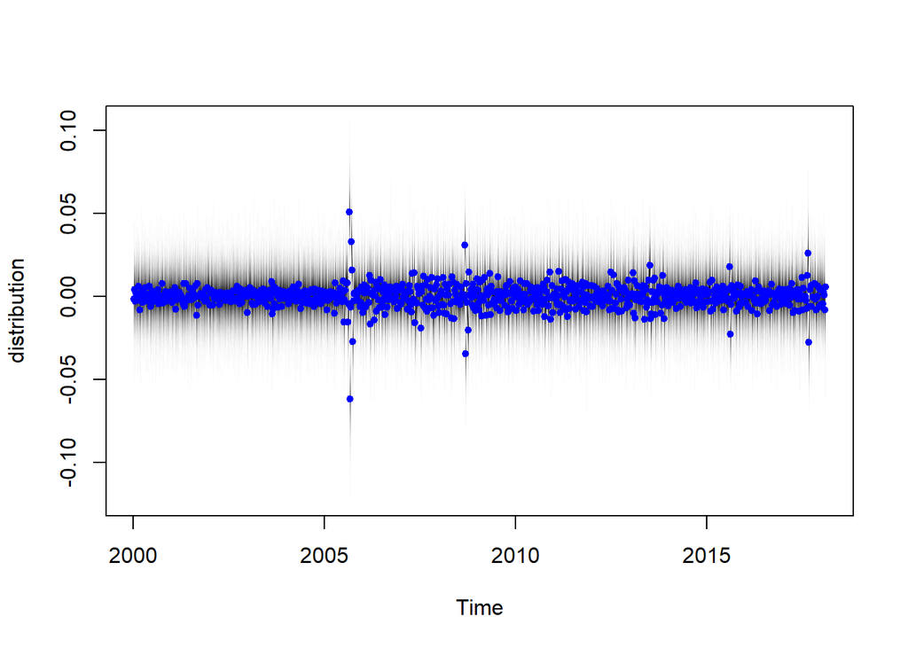

```r
PlotBstsResiduals(model.no.regressors, burn = SuggestBurn(.1, model.no.regressors), style = "dynamic")
```

Для прогнозирования будущих значений есть метод `predict()`. Например, прогноз на 12 недель вперед.

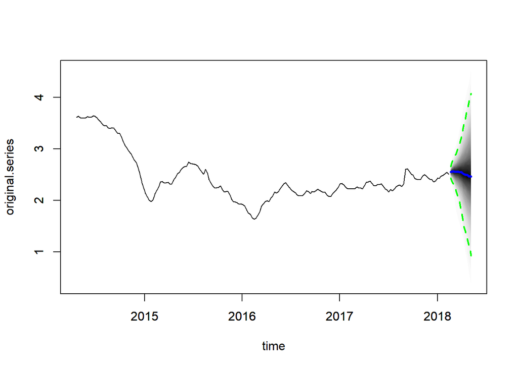

```r
pred1 <- predict(model.no.regressors, horizon = 12)
plot(pred1, plot.original = 200)
```

Тперь добавим все регрессоры в модель. Сначала подгоним bsts модель с экстра аргументом `expected.model.size`= 1, по умолчанию(см аргументы метода *bsts()* ).

Параметр `expected.model.size` - это число меньшее, чем количество регрессоров, представляющее собой ожидание количества значимых предикторов.

```r
model.default.expected.model.size<- bsts(y ~ .,
               state.specification = ss,
               niter = 1000,
               data = data.xts,seed = 1000)
```

```
## =-=-=-=-= Iteration 0 Mon Mar 29 23:58:35 2021
##  =-=-=-=-=
## =-=-=-=-= Iteration 100 Mon Mar 29 23:58:47 2021
##  =-=-=-=-=
## =-=-=-=-= Iteration 200 Mon Mar 29 23:58:58 2021
##  =-=-=-=-=
## =-=-=-=-= Iteration 300 Mon Mar 29 23:59:10 2021
##  =-=-=-=-=
## =-=-=-=-= Iteration 400 Mon Mar 29 23:59:22 2021
##  =-=-=-=-=
## =-=-=-=-= Iteration 500 Mon Mar 29 23:59:34 2021
##  =-=-=-=-=
## =-=-=-=-= Iteration 600 Mon Mar 29 23:59:45 2021
##  =-=-=-=-=
## =-=-=-=-= Iteration 700 Mon Mar 29 23:59:57 2021
##  =-=-=-=-=
## =-=-=-=-= Iteration 800 Tue Mar 30 00:00:09 2021
##  =-=-=-=-=
## =-=-=-=-= Iteration 900 Tue Mar 30 00:00:21 2021
##  =-=-=-=-=
```

```r
summary(model.default.expected.model.size)
```

```
## $residual.sd
## [1] 0.01347502
##
## $prediction.sd
## [1] 0.05338651
##
## $rsquare
## [1] 0.9997004
##
## $relative.gof
## [1] 0.1635075
##
## $size
##    Min. 1st Qu.  Median    Mean 3rd Qu.    Max.
##    2.00    2.00    2.00    2.04    2.00    3.00
##
## $coefficients
##                      mean           sd      mean.inc       sd.inc    inc.prob
## RWTC         6.408315e-03 2.267261e-04  0.0064083153 0.0002267261 1.000000000
## WGTSTUS1    -5.315954e-01 1.663270e-02 -0.5315953694 0.0166326999 1.000000000
## WTTSTUS1    -8.559435e-04 5.061458e-03 -0.0242109720 0.0134702171 0.035353535
## RBRTE        6.846131e-07 9.633360e-06  0.0001355534 0.0000000000 0.005050505
## dummy        0.000000e+00 0.000000e+00  0.0000000000 0.0000000000 0.000000000
## (Intercept)  0.000000e+00 0.000000e+00  0.0000000000 0.0000000000 0.000000000
```

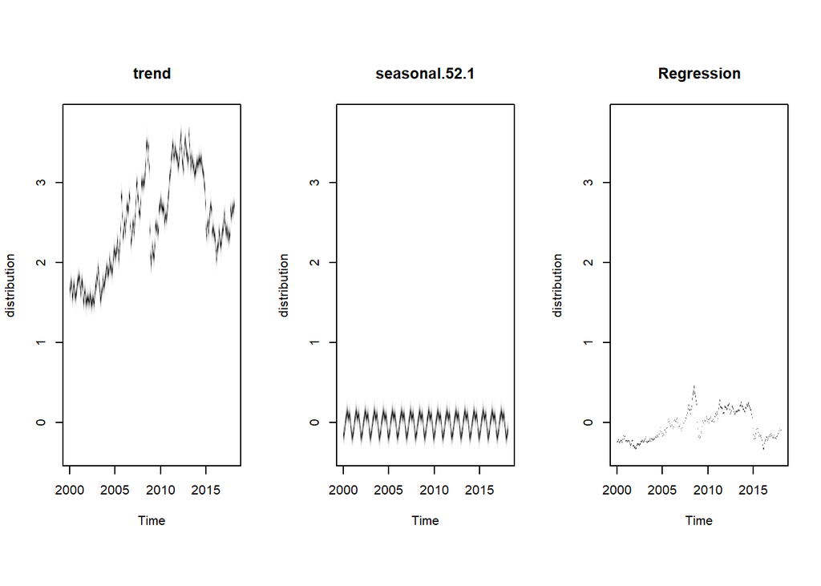

```r
plot(model.default.expected.model.size, "comp")
```

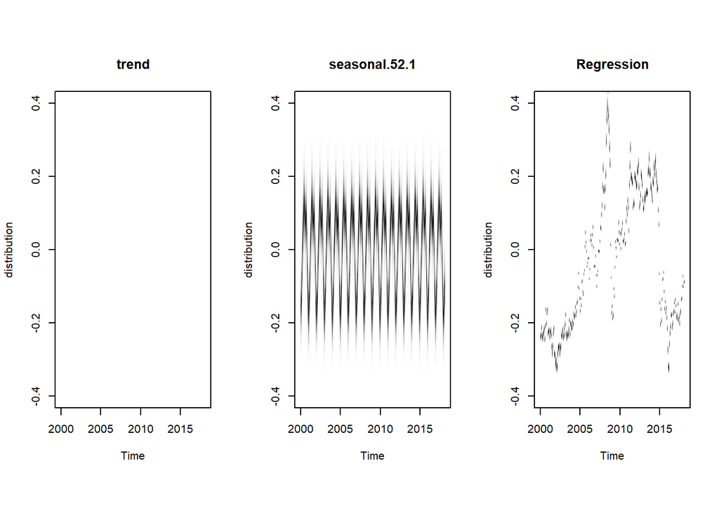

```r
plot(model.default.expected.model.size, "comp",ylim= c(-0.4,0.4))
```

Результаты оценивания всех копонент: тренда, сезонности и предикторов находятся в трех-мерных объектах `model.default.expected.model.size$state.contributions`.

```r
dim(model.default.expected.model.size$state.contributions)
```

```
## [1] 1000    3  945
```

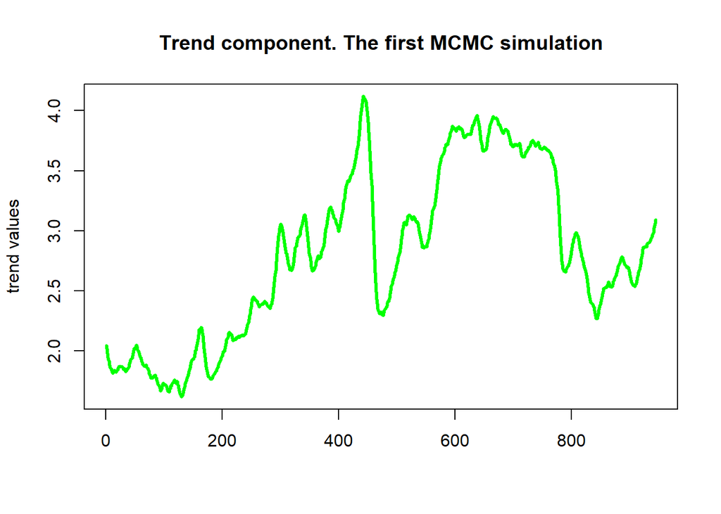

```r
matplot(model.default.expected.model.size$state.contributions[1,1,],type='l',col = 'green',main ='Trend component. The first MCMC simulation',ylab = 'trend values',lwd = 3)
```

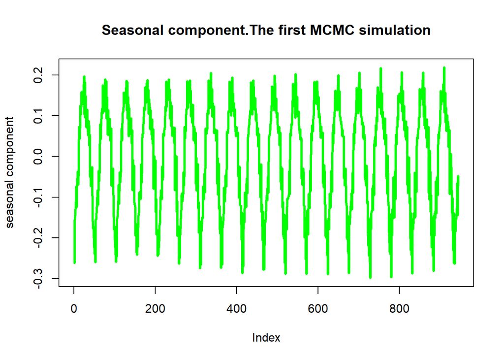

```r
plot(model.default.expected.model.size$state.contributions[1,2,],type='l',col = 'green',main ='Seasonal component.The first MCMC simulation',lwd = 3,ylab = 'seasonal component' )
```

График для первого периода сезонности

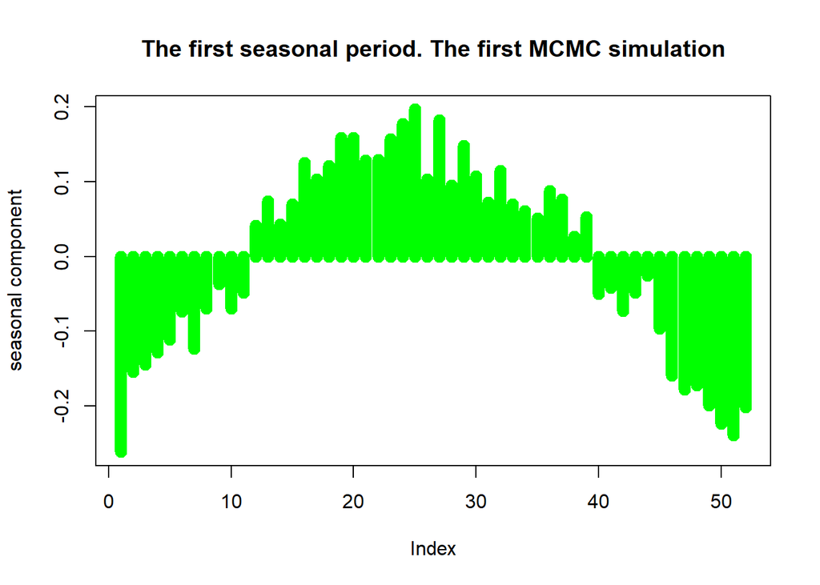

```r
plot(head(model.default.expected.model.size$state.contributions[1,2,],52),type='h',col = 'green',main ='The first seasonal period. The first MCMC simulation',lwd = 10,ylab = 'seasonal component')
```

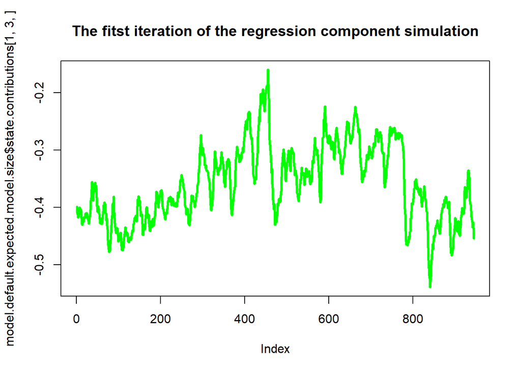

```r
plot(model.default.expected.model.size$state.contributions[1,3,],type='l',col = 'green',main ='The fitst iteration of the regression component simulation',lwd = 3)
```

Теперь оценим bsts модель с ожидаемым числом предикторов 3.

```r
model.expected.model.size.3 <- bsts(y ~ .,
               state.specification = ss,
               niter = 1000,
               data = data.xts,
               expected.model.size = 3,seed = 1000)
```

```
## =-=-=-=-= Iteration 0 Tue Mar 30 00:00:38 2021
##  =-=-=-=-=
## =-=-=-=-= Iteration 100 Tue Mar 30 00:00:50 2021
##  =-=-=-=-=
## =-=-=-=-= Iteration 200 Tue Mar 30 00:01:02 2021
##  =-=-=-=-=
## =-=-=-=-= Iteration 300 Tue Mar 30 00:01:14 2021
##  =-=-=-=-=
## =-=-=-=-= Iteration 400 Tue Mar 30 00:01:25 2021
##  =-=-=-=-=
## =-=-=-=-= Iteration 500 Tue Mar 30 00:01:37 2021
##  =-=-=-=-=
## =-=-=-=-= Iteration 600 Tue Mar 30 00:01:49 2021
##  =-=-=-=-=
## =-=-=-=-= Iteration 700 Tue Mar 30 00:02:01 2021
##  =-=-=-=-=
## =-=-=-=-= Iteration 800 Tue Mar 30 00:02:13 2021
##  =-=-=-=-=
## =-=-=-=-= Iteration 900 Tue Mar 30 00:02:25 2021
##  =-=-=-=-=
```

```r
summary(model.expected.model.size.3)
```

```
## $residual.sd
## [1] 0.0136398
##
## $prediction.sd
## [1] 0.05187572
##
## $rsquare
## [1] 0.999693
##
## $relative.gof
## [1] 0.2102339
##
## $size
##    Min. 1st Qu.  Median    Mean 3rd Qu.    Max.
##   4.000   4.000   4.000   4.027   4.000   5.000
##
## $coefficients
##                      mean           sd      mean.inc       sd.inc   inc.prob
## RBRTE        5.403684e-03 0.0001692311  0.0054036839 0.0001692311 1.00000000
## RWTC         1.130046e-03 0.0001628250  0.0011300455 0.0001628250 1.00000000
## WTTSTUS1    -5.868544e-01 0.0151003766 -0.5868544481 0.0151003766 1.00000000
## WGTSTUS1    -3.331422e-01 0.0342332533 -0.3331421732 0.0342332533 1.00000000
## dummy       -1.420748e-05 0.0000864207 -0.0005256766 0.0000000000 0.02702703
## (Intercept)  0.000000e+00 0.0000000000  0.0000000000 0.0000000000 0.00000000
```

Существует метод изображения регрессионных коэффициентов

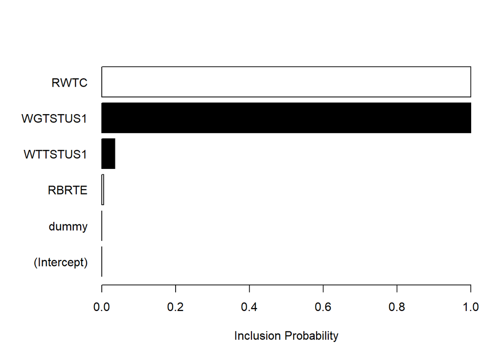

```r
plot(model.default.expected.model.size, "coef")
```

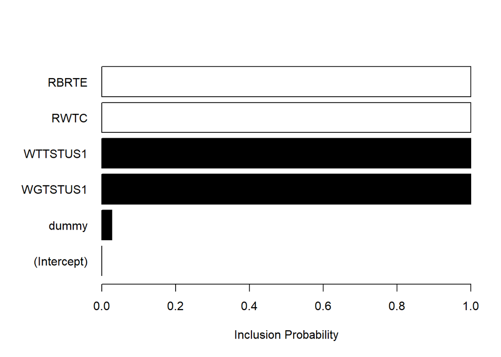

```r
plot(model.expected.model.size.3, "coef")
```

Во всех моделях предиктор `dummy` отмечен как незначимый.

Существует также метод `plot()`, показывающий какой из предикторов был наиболее значим в каждый момент времени.

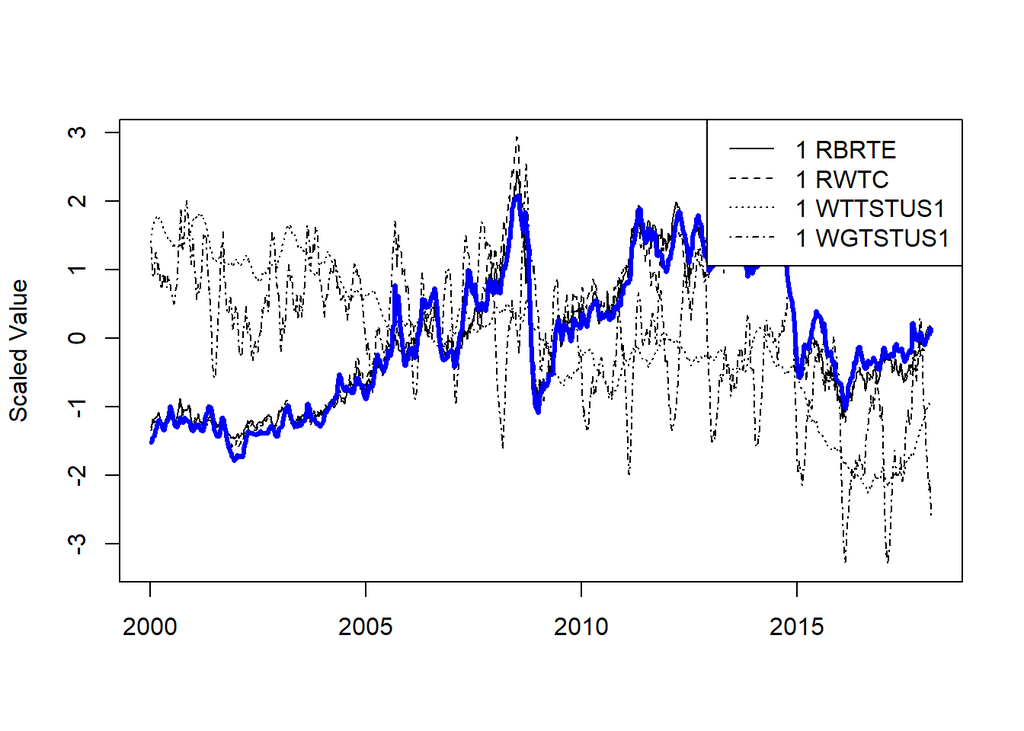

```r
plot(model.expected.model.size.3, "predictors")
```

В процессе оценки модели вычисляются ошибки прогноза за один шаг времени $y_t−E(y_t|Y_{t−1},\theta)$ , где $Y_{t−1}=y_1,…,y_{t−1}$. Эти ошибки могут быть получены из bsts модели вызовом функции `bsts.prediction.errors()`.

```r
   one_step_error<- bsts.prediction.errors(model.no.regressors)
```

Ошибки удобны для сравнения разных bsts моделей, подогнанных к одним и тем же данным. Сравнение моделей осуществлячеся вызов функции `CompareBstsModels`, который показан ниже.

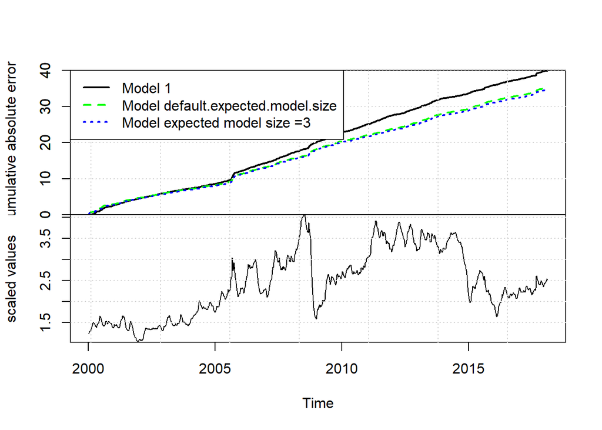

```r
  CompareBstsModels(list("Model 1" = model.no.regressors,
                       "Model default.expected.model.size" = model.default.expected.model.size,
                       "Model expected model size =3" = model.expected.model.size.3),
                  colors = c("black","green", "blue"))
```

Результат вызова картинка из двух панелей. На нижней панели изображен исследуемый временной ряд. На верхней панели выдается накопленаая средняя ошибка прогноза за один шаг времени для каждой из моделей. Что удобно для их сравнения.